# U6. La escuela neoclásica. La revolución marginalista. La microeconomia en Francia.

Historia del Pensamiento y del Análisis Económico

Sebastian Freille

Universidad Nacional de Córdoba

# El avance fuera de Inglaterra

## Cambio de foco y variantes continentales

- La escuela clásica inglesa fue la primera que, en su conjunto, utilizó métodos formales y abstracción guiada por la lógica deductiva para estudiar fenómenos económicos
- Pero la difusión de las ideas clásicas pronto impactaría positivamente sobre el surgimiento de análisis económico en el continente, Francia y Austria fueron dos ejemplos de ello
- Pero a diferencia de las preocupaciones de la escuela clásica inglesa –la renta, el producto, la población y el crecimiento- el foco del análisis estuvo en la microeconomía
  - precios, cantidades, y estructuras de mercado

## La irrupción del análisis microeconómico

- Se realizaron avances en temas de finanzas públicas y economía del bienestar; sobre decisiones de localización y costos de transporte;
- Además se sentaron las bases sobre las cuales se desarrollan las teorías de discriminación de precios y de diferenciación del producto
- Y fundamentalmente se terminó de cerrar definitivamente el problema del valor con la contribución fundamental de la teoría de la utilidad de Jevons
- Comencemos ahora con las contribuciones de los “ingenieros” franceses que dieron un particular impulso a la introducción del análisis microeconómico

# Antoine-Agustin Cournot [1801-1877]

## Cournot [1801-1877]: Vida

- Una mente muy original, estudió matemática en la *Ecole Normale* de París y su doctorado en la Universidad de Paris y tuvo contacto fluido con físicos e ingenieros
- Gracias a su amistad con Poisson (si, el de la distribución!) se aseguró posiciones docentes y de gestión académica –
- Su voraz apetito por la lectura científica le causaron una ceguera progresiva que influyó sobre la calidad de su trabajo
  - su principal contribución está en el libro *Recherches sur les principes mathématiques de la théorie des richesses*
- Murió casi en la más absoluta anonimidad en relación a su trabajo y contribución –salvo Walras.

## Cournot [1801-1877]: Sobre el método

- Valoró y abogó por el uso de las matemáticas como procedimiento abreviado para expresar ideas complejas
- Pero también decía que su principal uso no era para lograr cálculos numéricos sino “para encontrar relaciones entre magnitudes, entre funciones” –relativizaba el rol de lo empírico en el proceso de la ciencia
- Cournot descubre “la ley de la demanda”, $D=F(P)$ $\longrightarrow$ Cournot comprendió perfectamente el supuesto *ceteris paribus*

## Cournot [1801-1877]: Sobre el método (cont.)

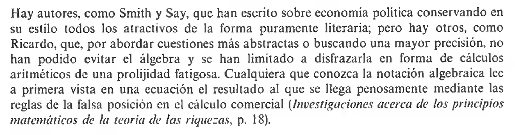

Figura 1: En defensa de las matemáticas

## Cournot [1801-1877]: Sobre el método (cont.)

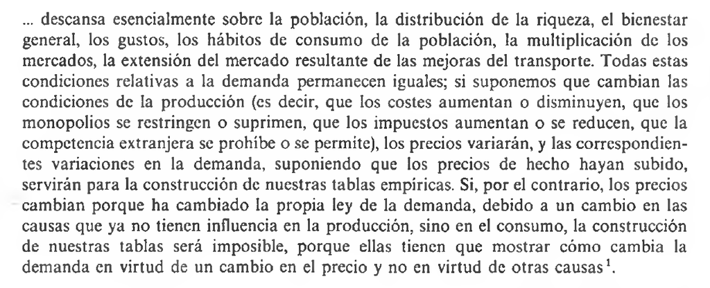

Figura 2: El supuesto *ceteris paribus*

## Cournot [1801-1877]: Sobre el método (cont.)

- Rechazó la utilidad como fundamento de su función de demanda, hace una aproximación empírica a la misma $\longrightarrow$ “la venta, o la demanda…crece en general cuando el precio desciende”
- Su especificación teórica –$D$ continua y con pendiente negativa- se deduce de la observación y de simplificaciones; pero la teoría se eleva por encima de los hechos y puede usarse para hacer deducciones y generalizaciones
- Como puede notarse, Cournot fue muy lúcido en cuanto a formulación de teorías y construcción de modelos

## Cournot [1801-1877]: los modelos microeconómicos

- Usó estos metódos y teorías para crear **modelos de comportamiento de la empresa**. Entre ellos, dos de sus modelos más importantes fueron: 1) modelo del monopolio, 2) modelo del oligopolio
- El primero es el **modelo del manantial de agua** y analiza el problema de la maximización del beneficio del productor
- El segundo es tal vez la más famosa de sus teorías, el famoso **modelo de duopolio de Cournot** donde introdujo un vendedor adicional a su modelo de monopolio

## Cournot [1801-1877]: el monopolio

- El monopolista cobra un precio $p$ tal que el ingreso total $pF(p)$ sea máximo –cuando $CM=IM$. Si costos son nulos, el máximo es cuando el $IM=0$
- Recuerdo que $\Pi=TR-TC$ $\longrightarrow$ si $TC=0$ entonces $\Pi=TR$ –el monopolista con costos nulos vende más $q$ que el monopolista de costos positivos [$Q_{n}>Q_{c}$
- Es decir, vende cuando maxizima sus ingresos brutos –que fue la gran demostración de Cournot
  - el caso de costos positivos revela el “principio marginalista” $\longrightarrow$ $MC=MR$

## Cournot [1801-1877]: el monopolio (cont.)

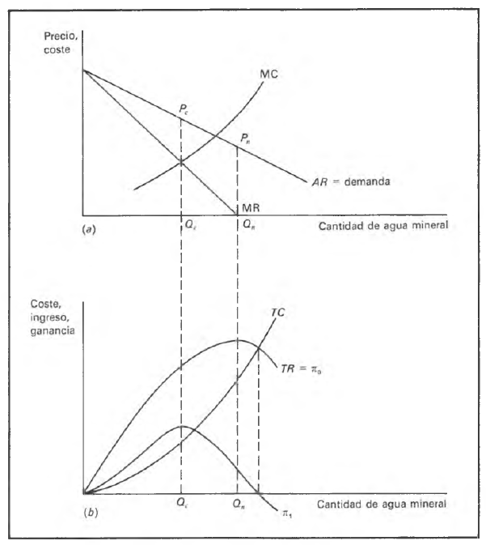

Figura 3: Monopolio: costos positivos y nulos

## Cournot [1801-1877]: el duopolio

- Consideró ahora dos vendedores $A$ y $B$ que conocen la curva de demanda agregada de su producto
- Cada uno de ellos supone que la decisión del otro en relación a mantener/aumentar la $q$ es independiente de lo que haga uno
- Supuso además que $A$ y $B$ (cada uno) podían suministrar *toda* el agua demandada. Nuevamente supone que la producción no tiene costo
- Su gran contribución original fue la (hoy) famosa **curva (función) de reacción**

## Cournot [1801-1877]: el duopolio (cont.)

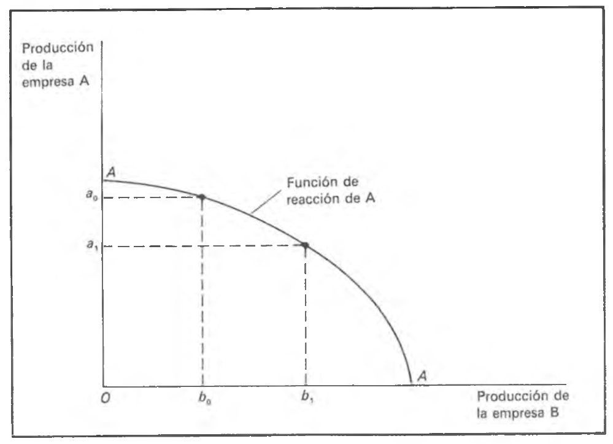

Figura 4: La función de reacción

## Cournot [1801-1877]: el duopolio (cont.)

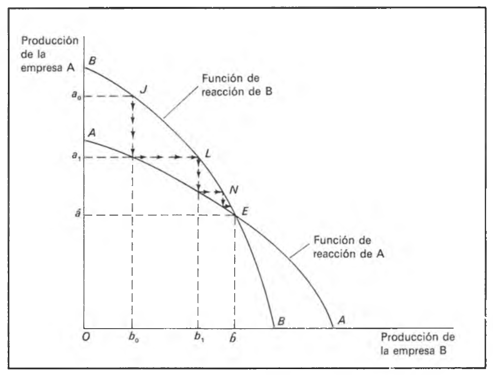

Figura 5: Funciones de reacción y determinación de $q$

## Cournot [1801-1877]: el duopolio (cont.)

- El punto $E$ representa el equilibrio y es estable –una posición a la que regresan sin por alguna razón no estuvieran
- En este punto, los duopolistas se reparten el beneficio y *cargan el mismo precio* –más bajo que el que cargarían en monopolio pero más alto que el de competencia
- Fue muy preciso respecto de las relaciones entre cantidades vendidas en monopolio, duopolio y competencia

## Cournot [1801-1877]: evaluación

- Si bien su fama se debe al modelo de duopolio, nos dejó muchas otras intuiciones
- Sus modelos de monopolio y duopolio fueron sujeto de muchas críticas –supuesto de inacción ante cambios en el precio del otro[Bertrand, Edgeworth]. Incluso ante la evidencia repetida disponible
- Aún así, este modelo dio pie a una muy fructífera linea de investigación en economía en relación a la interdependencia estrategica y la variación conjetural –i.e. supuesto de como reacciona un vendedor a las acciones del otro

# Jules Dupuit [1804-1866]

# Jules Dupuit [1804-1866]: vida

- Fue en paralelo a la figura de Cournot, el otro estandarte del análisis microeconómico en Francia. Al igual que Cournot, concebía la economía como una vocación y no como profesión
- Estudió ingenieria en prestigiosos centros educativos –tuvo una ilustre carrera como ingeniero sobre todo como gestor y director- y se interesó por la economía
- Sus contribuciones a la economía no fueron de menor calibre aunque la mayoría encontradas en revistas y no en libros

## Jules Dupuit [1804-1866]: sobre el método

- Escribió casi en paralelo con Cournot pero sin conocerse ni leerse – su método guardaba relación con el de Cournot dado que para el la economía política era una ciencia combinada entre razón y observación
- En efecto combinó 3 (tres) elementos:
  1. temas de interes y relevancia economica
  2. hechos relevantes observados y estadísticas
  3. análisis matemático –lógica deductiva y análisis gráfico
- Asi las teorías concebidas se contrastarían con nuevos datos y actualizarían

## Jules Dupuit [1804-1866]: utilidad marginal y demanda

- Fue el primer economista que presentó una discusión del concepto de UM y lo relacionó con la curva de demanda (en 1844).
  - argumentó que la utilidad que un individuo obtiene de un *stock* de bienes se determina por el uso a que se destinan las *últimas unidades del stock*
- Jevons reconoció honorablemente que Dupuit era quien debía ser *“credited with the earliest perfect comprehension of the theory of utility”*
- Todo consumidor “atribuye una utilidad diferente al mismo objeto, según la cantidad que consume”
- Elaboró un ejemplo con el uso de cantidades crecientes de agua y lo vinculó con las bajas en el precio

## Jules Dupuit [1804-1866]: utilidad marginal y demanda

> Si el precio se redujese en 20 francos, el individuo demandaría 4 hectolitros para poder limpiar su casa todos los días; si se la dan a 10 francos, pedirá 10 hl., para poder regar su jardín; a 5 francos, pedirá 20 hl. para instalarse una fuente; a 1 franco, pediría 100 hl. para disponer de una corriente continua y así sucesivamente. Es la necesidad menos apremiante que se siente de una mercancía, no la más apremiante, lo que define el valor de cambio de todo el stock de bienes.

## Jules Dupuit 1804-1866]: utilidad marginal y demanda (cont.)

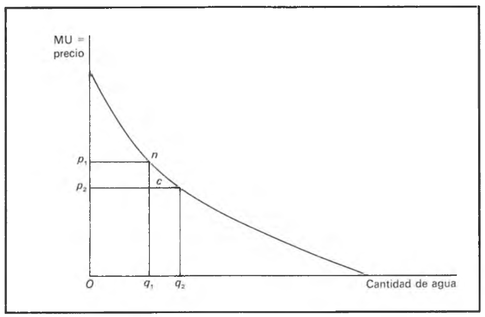

Figura 6: Cantidad y utilidad marginal (precio)

## Jules Dupuit [1804-1866]: utilidad marginal y demanda

> Si en una tabla de dos columnas se colocan en la primera todos los precios, desde 0, al que le corresponde un mayor consumo, hasta el precio al que ya no se consume nada; y en la segunda, en relación con cada precio, se coloca la correspondiente cantidad consumida, tendremos la representación exacta de lo que llamamos la ley del consumo **[Jules Dupuit, *Dictionnaire de l’economie politique*]**

## Jules Dupuit [1804-1866]: utilidad marginal y demanda

[figure not shown]

Figura 7: La curva de demanda

## Jules Dupuit [1804-1866]: utilidad marginal y demanda

- Expresaba la curva de demanda como $Q_d=f(p)$ y colocó la variable independiente en el eje de las $x$ y la depediente en el eje de las $y$ –quien rompió con esto fue Alfred Marshall porque el trató al *precio como función de la cantidad*
- Al vincular la curva de demanda con la teoría de la utilidad básicamente funda la *economía del bienestar*
- En su grafico distingue las areas delimitadas por el precio que efectivamente pagan y la que está por encima del precio pagado le llama “utilidad que queda a los consumidores”

## Jules Dupuit [1804-1866]: otras contribuciones (cont.)

- Exploró el comportamiento del monopolista –regla de maximización del beneficio –el rendimiento/beneficio bruto en caso de costos cero y el rendimiento/beneficio neto en caso de costos (variables) positivos
- Pero su teoría la realizó en terminos del beneficio neto
- También destacó otro elemento que tomaría Marshall $\longrightarrow$ relacionó el ingreso del monopolista con el excedente del consumidor
- Finalmente la discriminación de precios posibilitaría aumentar/disminuir via políticas de discriminación de precios

## Jules Dupuit [1804-1866]: otras contribuciones (cont.)

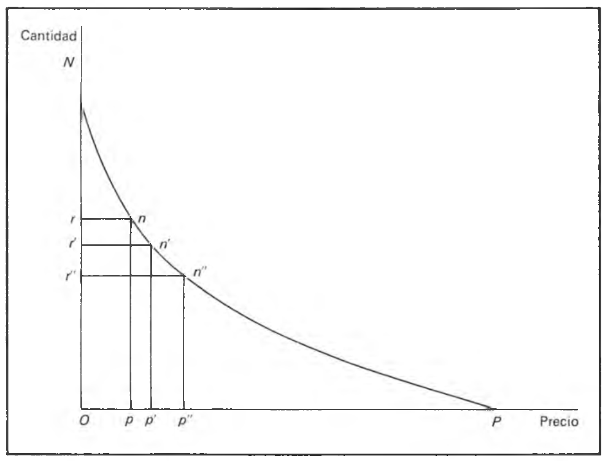

Figura 8: Monopolio con discriminación

## Jules Dupuit [1804-1866]: otras contribuciones (cont.)

- Finalmente, realizó contribuciones en el **análisis beneficio-costo** munido de su descubrimiento de la curva de $UM$
- La regla general era que el gobierno debía proveer los bienes si tal que el costo anual pudiera cubrirse dejando alguna “utilidad neta” –es decir, si $IM=CM$
- Distinguió entre un monopolio privado (discriminación total) y uno gestionado por el gobierno (discriminación restringida) $\longrightarrow$ es decir podría decidir maximizar el excedente de los consumidores
  - esto no sería posible con un monopolista privado
- En esto hubo un tímido interés por el tema de la distribución de la renta

## Resumen de las contribuciones

- Fueron ingenieros y economistas franceses quienes primero se acercan a formalizar la **teoría de la empresa** $\longrightarrow$ análisis de maximización del producto y beneficio (Cournot) en diferentes estructuras junto a las teorías de la utilidad y bienestar (Dupuit)
- Recordatorio que muchas veces ideas novedosas fueron “pasadas por alto” por la corriente principal –note las fechas en que escribieron
- Nota de caución en relación a la sobreespecialización disciplinar y la importancia de abrir la investigación disciplinar no sólo a otras metodologías, disciplinas y enfoques